# Group 6: Ordinal Logistic Regression

Do people with higher carbohydrate intake feel more sleepy during the day?

Yuying Wang Yehao Zhang

12/11/2019

## Introduction

Carbohydrates are one of 3 macronutrients found in food, and also the body’s main source of energy in a healthy, balanced diet. They are broken down into glucose (sugar) before being absorbed into the bloodstream, and then the glucose enters the body’s cells with the help of insulin. According to the National Sleep Foundation, carbohydrates could cause blood sugar to spike quickly, followed by a drop that leaves people feeling tired after eating.

So, it brought up our interest to examine this specific relationship through data *NHANES 2015-2016*. In the following analysis done in Stata and R, an Ordinal Logistic Regression model is fit on the response variable **sleepy** and independent variable **carbohydrate intake ratio**, controlling for other factors found relevant in the data to study if there is evidence supporting a positive relationship and answer the question **Do people with higher carbohydrate intake feel more sleepy during the day?**

## Data

The National Health and Nutrition Examination Survey (NHANES) is a program of studies designed to assess the health and nutritional status of adults and children in the United States. Three data sets from 2015 to 2016 are used in the analysis, and they are *[Dietary Interview - Total Nutrient Intakes, First Day (DR1TOT_I)](https://wwwn.cdc.gov/Nchs/Nhanes/2015-2016/DR1TOT_I.htm)*, *[Sleep disorders (SLQ_I)](https://wwwn.cdc.gov/Nchs/Nhanes/2015-2016/SLQ_I.htm)*, and *[Demographic Variables and Sample Weights (DEMO_I)](https://wwwn.cdc.gov/Nchs/Nhanes/2015-2016/DEMO_I.htm)*.

- **DR1TOT_I.XPT: Dietary Interview - Total Nutrient Intakes, First Day**

  We define our key independent variable **carb_level** as a 3-category factor indicating the ratio of carbs intake out of daily calorie intake.

  First, the ratio is calculated through $\small{\text{4*DR1TCARB/DR1TKCAL}}$, where 4 represents the unit conversion from gram to kcal for carbohydrate. Then, according to the carbohydrate intake suggested by the Dietary Guidelines for Americans, which is 45 to 65 percent of total diet, a factor variable is created by assigning 0 to ratios that fall in this group, 1 to ratios lower than the suggested level, and 2 to ratios higher than the suggested level.

  | Variable | Description |
  | --- | --- |
  | DR1TKCAL | Energy (kcal) |
  | DR1TCARB | Carbohydrate (gm) |
  | carb_level | Ratio of carbs intake out of daily calorie intake: 0 - suggested range, 1 - below range, 2 - above range |

- **SLQ_I.XPT: Sleep Disorders**

  We choose **sleepy_freq** as the response variable in the analysis. **sleep_hr** is our control variable that might effect the response variable.

  | Variable | Rename | Description |
  | --- | --- | --- |
  | SLD012 | sleep_hr | Sleep hours |
  | SLQ120 | sleepy_freq | How often feel overly sleepy during day? 0 - Never, 1 - Rarely, 2 - Sometimes, 3 - Often, 4 - Almost always, 9 - Don’t know |

- **DEMO_I.XPT: Demographic Variables and Sample Weights**

  We include **age_yr**, **female** and **winter** as control variables in the regression model. Age below 5 are discarded from the sample because [study](https://hqlo.biomedcentral.com/articles/10.1186/1477-7525-5-1) finds children as young as 5 years old can reliably and validly self-report their health-related quality of life.

  | Variable | Rename | Description |
  | --- | --- | --- |
  | RIDAGEYR | age_yr | Age in years at screening: >=5 |
  | RIAGENDR | female | Gender: 0 - male, 1 - female |
  | RIDEXMON | winter | Six month time period: 0 - May 1 through October 31, 1 - November 1 through April 30 |

## Methods

And the log odds is defined as
$$%
log\frac{P(Y\leq i)}{P(Y>i)} = logit(P(Y\leq i))
%$$

The ordinal logistic regression model is defined as
$$%
logit(P(Y\leq i)) = \beta_{i0}+\beta_1x_1+...+\beta_jx_j
%$$
where $x_1,...x_j$ are the independent variables. The intercepts are different for each category but the slopes are constant across categories because of the proportional odds assumption, which means the effect of each independent variable is assumed to be the same over all levels of our response variable.

So here in our model
$$%
logit(P({sleepyfreq}\leq i)) = \beta_{i0}+\beta_1{carblevel}+\beta_2sleephr +\beta_3female + \beta_4ager + \beta_5winter
%$$

## Core Analysis

### R

As discussed in the data section, we first perform data cleaning on each dataset and merge them into one. Finally, the rows that contain NAs are removed.

```r
## Data
# Import data
sleep_disorder <- setDT(read.xport("SLQ_I.XPT"))
tot_nutrition_d1 <-setDT(read.xport("DR1TOT_I.XPT"))
demo <- setDT(read.xport("DEMO_I.XPT"))
# Data cleaning
sleep_disorder = sleep_disorder[SLQ120 <= 4, .(respondent_ID = SEQN, sleep_hr = SLD012, sleepy_freq = factor(SLQ120,))]
tot_nutrition = tot_nutrition_d1[, .(respondent_ID = SEQN, energy = DR1TKCAL, CHO = DR1TCARB)
                                ][, .(p_CHO = CHO*4/energy), by = respondent_ID
                                ][, carb_level := "suggested range"
                                ][p_CHO <= 0.45, carb_level := "below range(<=0.45)"
                                ][p_CHO >= 0.65, carb_level := "above range(>=0.65)"
                                ][, carb_level := factor(carb_level)
                                ]
demo = demo[RIDAGEYR >= 5, .(respondent_ID = SEQN, winter = factor(RIDEXMON), female = factor(RIAGENDR-1), age = RIDAGEYR)]
# Merge these three datasets
sleep = merge(sleep_disorder, tot_nutrition, by = "respondent_ID") %>%
  merge(. , demo, by = "respondent_ID") %>%
  na.omit(.)
sleep # the cleaned data
```

```
      respondent_ID sleep_hr sleepy_freq     p_CHO          carb_level winter
   1:         83732      5.5           3 0.4341157 below range(<=0.45)      1
   2:         83733      8.0           0 0.4815789     suggested range      1
   3:         83734      7.0           3 0.4907816     suggested range      2
   4:         83735      6.5           4 0.4716119     suggested range      2
   5:         83737      9.0           1 0.4706442     suggested range      1
  ---
5549:         93691      8.0           0 0.6445230     suggested range      1
5550:         93695      9.5           0 0.3783932 below range(<=0.45)      2
5551:         93696      8.5           0 0.4758882     suggested range      1
5552:         93697     10.0           2 0.4330390 below range(<=0.45)      2
5553:         93702      7.5           2 0.2586888 below range(<=0.45)      2
      female age
   1:      0  62
   2:      0  53
   3:      0  78
   4:      1  56
   5:      1  72
  ---
5549:      0  25
5550:      1  76
5551:      0  26
5552:      1  80
5553:      1  24
```

In the next step, we need to assess whether the ordinal regression is appropriate for this analysis. Now the dataset “sleep” is ready to fit the ordered logistic regression model.

```r
# fit ordered logit model
m <- polr(sleepy_freq ~ sleep_hr + carb_level + winter + female + age, data = sleep, Hess = TRUE)
# view a summary of the model
summary(m)
```

```
Call:
polr(formula = sleepy_freq ~ sleep_hr + carb_level + winter +
    female + age, data = sleep, Hess = TRUE)

Coefficients:
                                  Value Std. Error t value
sleep_hr                      -0.100334   0.015812 -6.3453
carb_levelbelow range(<=0.45)  0.160694   0.100284  1.6024
carb_levelsuggested range      0.049073   0.097899  0.5013
winter2                        0.178879   0.048170  3.7135
female1                        0.244488   0.048429  5.0483
age                           -0.007783   0.001242 -6.2650

Intercepts:
    Value    Std. Error t value
0|1  -2.4075   0.1713   -14.0541
1|2  -1.2088   0.1692    -7.1458
2|3   0.2018   0.1683     1.1985
3|4   1.5981   0.1715     9.3185

Residual Deviance: 16834.78
AIC: 16854.78
```

To be valid to fit the ordinal logistic regression model, the proportional odds assumption, also known as the parallel regression assumption must be met. It assumes the effect of independent variables is identical for each log of odds computation. In R, we can perform a brant test using the brant function from the brant package. The result generated by the brant test suggests that the parallel regression assumption does not hold since not all p-values is larger than 0.05.

```r
brant(m)
```

```
--------------------------------------------------------------------
Test for                X2  df  probability
--------------------------------------------------------------------
Omnibus                 56.58   18  0
sleep_hr                16.79   3   0
carb_levelbelow range(<=0.45)   4.03    3   0.26
carb_levelsuggested range       0.92    3   0.82
winter2                 21.06   3   0
female1                 7.63    3   0.05
age                 5.36    3   0.15
--------------------------------------------------------------------

H0: Parallel Regression Assumption holds
```

```
                                      X2 df  probability
Omnibus                       56.5812155 18 7.212417e-06
sleep_hr                      16.7922240  3 7.797934e-04
carb_levelbelow range(<=0.45)  4.0292520  3 2.583227e-01
carb_levelsuggested range      0.9187199  3 8.209081e-01
winter2                       21.0592828  3 1.023335e-04
female1                        7.6333217  3 5.423001e-02
age                            5.3580699  3 1.473784e-01
```

Next, the p-values are calculated by comparing the t-value against the standard normal distribution. The 95% CI for the parameter estimates could be obtained using the “confint” function.

```r
# store the coefficientts
mcoef <- coef(summary(m))
# calculate p values
p <- pnorm(abs(mcoef[, "t value"]), lower.tail = FALSE) *2
mcoef = cbind(round(mcoef,3), "pvalue" = round(p,3))
mcoef
```

```
                               Value Std. Error t value pvalue
sleep_hr                      -0.100      0.016  -6.345  0.000
carb_levelbelow range(<=0.45)  0.161      0.100   1.602  0.109
carb_levelsuggested range      0.049      0.098   0.501  0.616
winter2                        0.179      0.048   3.714  0.000
female1                        0.244      0.048   5.048  0.000
age                           -0.008      0.001  -6.265  0.000
0|1                           -2.408      0.171 -14.054  0.000
1|2                           -1.209      0.169  -7.146  0.000
2|3                            0.202      0.168   1.198  0.231
3|4                            1.598      0.171   9.319  0.000
```

```r
# 95% CI
(ci <- round(confint(m), 3))
```

```
                               2.5 % 97.5 %
sleep_hr                      -0.131 -0.069
carb_levelbelow range(<=0.45) -0.036  0.357
carb_levelsuggested range     -0.143  0.241
winter2                        0.084  0.273
female1                        0.150  0.339
age                           -0.010 -0.005
```

Since the coefficients from the model is difficult to interpret because they are scaled interms of logs. We could convert them into odds ratios.

```r
# odds ratios
round(exp(coef(m)),3)
```

```
                     sleep_hr carb_levelbelow range(<=0.45)
                        0.905                         1.174
    carb_levelsuggested range                       winter2
                        1.050                         1.196
                      female1                           age
                        1.277                         0.992
```

```r
# odds ratios & CI
ci = exp(cbind(OR = coef(m), ci))
round(ci,3)
```

```
                                 OR 2.5 % 97.5 %
sleep_hr                      0.905 0.877  0.933
carb_levelbelow range(<=0.45) 1.174 0.965  1.429
carb_levelsuggested range     1.050 0.867  1.273
winter2                       1.196 1.088  1.314
female1                       1.277 1.162  1.404
age                           0.992 0.990  0.995
```

### Stata

1. Data import and cleaning

Three data sets are imported into Stata and variables are recoded or created.

```stata
* import data and keep and rename relevant variables
* import total nutrient day 1
fdause DR1TOT_I.XPT, clear
quietly compress
gsort +seqn
generate carb_ratio = dr1tcarb*4 / dr1tkcal
* 0 for carb_ratio between 0.45 and 0.65
generate carb_level = 0
replace carb_level = 1 if carb_ratio <= 0.45
replace carb_level = 2 if carb_ratio >= 0.65
keep seqn carb_level
save DR1TOT.dta, replace
* import sleep disorder data
fdause SLQ_I.XPT, clear
quietly compress
gsort +seqn
keep seqn sld012 slq120
* drop 'dont know' response
drop if slq120 == 9
rename sld012 sleep_hr
rename slq120 sleepy_freq
merge 1:1 seqn using DR1TOT.dta
drop _merge
save DRTOT_SLP.dta, replace
* import demographics data
fdause DEMO_I.XPT, clear
quietly compress
gsort +seqn
generate winter = 0
replace winter = 1 if ridexmon == 1
* 0 male 1 female
generate female = riagendr - 1
keep seqn female ridageyr winter
rename ridageyr age_yr
keep if age_yr >= 5
merge 1:1 seqn using DRTOT_SLP.dta
keep if _merge == 3
drop _merge
rename seqn respondent_id
label variable winter "1: November 1 through April 30"
label variable female "1: female, 0: male"
label variable carb_level "Ratio of carbs intake out of daily calorie intake"
label define sleepy 0 "Never" 1 "Rarely" 2 "Sometimes" 3 "Often" 4 "Almost always", add
label values sleepy_freq  sleepy
label define level 0 "suggested range" 1 "below range(<=0.45)" 2 "above range(>=0.65)", add
label values carb_level level
save DRTOT_SLP_DEMO.dta, replace
```

```
(1,218 missing values generated)


(2,715 real changes made)

(1,801 real changes made)


file DR1TOT.dta saved





(5 observations deleted)

    Result                           # of obs.
    -----------------------------------------
    not matched                         3,750
        from master                       264  (_merge==1)
        from using                      3,486  (_merge==2)

    matched                             6,058  (_merge==3)
    -----------------------------------------


file DRTOT_SLP.dta saved





(4,594 real changes made)




(1,398 observations deleted)

    Result                           # of obs.
    -----------------------------------------
    not matched                         1,427
        from master                        96  (_merge==1)
        from using                      1,331  (_merge==2)

    matched                             8,477  (_merge==3)
    -----------------------------------------

(1,427 observations deleted)










file DRTOT_SLP_DEMO.dta saved
```

2. Descriptive statistics

```
. use DRTOT_SLP_DEMO.. list in 1/6

     +----------------------------------------------------------------+
  1. | respon~d | age_yr | winter | female | sleep_hr |   sleepy_freq |
     |    83732 |     62 |      1 |      0 |      5.5 |         Often |
     |----------------------------------------------------------------|
     |                               carb_level                       |
     |                      below range(<=0.45)                       |
     +----------------------------------------------------------------+

     +----------------------------------------------------------------+
  2. | respon~d | age_yr | winter | female | sleep_hr |   sleepy_freq |
     |    83733 |     53 |      1 |      0 |        8 |         Never |
     |----------------------------------------------------------------|
     |                               carb_level                       |
     |                          suggested range                       |
     +----------------------------------------------------------------+

     +----------------------------------------------------------------+
  3. | respon~d | age_yr | winter | female | sleep_hr |   sleepy_freq |
     |    83734 |     78 |      0 |      0 |        7 |         Often |
     |----------------------------------------------------------------|
     |                               carb_level                       |
     |                          suggested range                       |
     +----------------------------------------------------------------+

     +----------------------------------------------------------------+
  4. | respon~d | age_yr | winter | female | sleep_hr |   sleepy_freq |
     |    83735 |     56 |      0 |      1 |      6.5 | Almost always |
     |----------------------------------------------------------------|
     |                               carb_level                       |
     |                          suggested range                       |
     +----------------------------------------------------------------+

     +----------------------------------------------------------------+
  5. | respon~d | age_yr | winter | female | sleep_hr |   sleepy_freq |
     |    83736 |     42 |      0 |      1 |        . |        Rarely |
     |----------------------------------------------------------------|
     |                               carb_level                       |
     |                          suggested range                       |
```

[output cut: 20 more lines]

```
              Total |     1,100      1,399      1,962      1,093 |     6,058

                    | How often
                    |    feel
                    |   overly
                    |   sleepy
     Ratio of carbs |   during
intake out of daily |    day?
     calorie intake | Almost al |     Total
--------------------+-----------+----------
    suggested range |       263 |     3,073
below range(<=0.45) |       168 |     2,117
above range(>=0.65) |        73 |       868
--------------------+-----------+----------
              Total |       504 |     6,058
```

3. Model assumption

Due to the fact that our response variable **sleepy_freq** is an ordinal factor, an ordinal logistic regression is fit on the data. Besides the requirement of dependent variable measured on an ordinal level, this model also assumes 1) no multicollinearity among independent variables and 2) proportional odds, which means the effect of each independent variable is assumed to be the same over all levels of our response variable. In Stata, **gologit2** will output a message if there is any collinear predictors and automatically drop that variables, so we are left with **Brant Test** to check if the other assumption is met.

```
. use DRTOT_SLP_DEMO.. * ordered logistic regression (proportional odds assumption)
. quietly ologit sleepy_freq i.carb_level sleep_hr female age_yr winter

. oparallel, brant

Test of the parallel regression assumption

                 |   Chi2     df  P>Chi2
-----------------+----------------------
           Brant |   59.7     18   0.000
```

4. Alternative approach

As shown in the results above, the proportional odds assumption is violated, so next we will try the unrestrictive Generalized Logistic Regression model that does not hold the assumption of proportional odds. However, the generalized model does not assume the response to be ordinal, can lead to negative probabilities, and is hard to interpret. So we do not consider this model.

```
. use DRTOT_SLP_DEMO.. * generalized
. quietly gologit2 sleepy_freq i.carb_level sleep_hr female age_yr winter, stor
> e(golog)

. * same as ologit
. quietly gologit2 sleepy_freq i.carb_level sleep_hr female age_yr winter, stor
> e(olog) pl

. * compare generalized and ordinal
. lrtest olog golog

Likelihood-ratio test                                 LR chi2(18) =     56.92
(Assumption: olog nested in golog)                    Prob > chi2 =    0.0000
```

5. Coefficient table and Marginal effects

It is common that the assumption of proportional odds is not met in real data sets. And we want to retain the original value of the data to eliminate loss of information, so we turn back to **Ordinal logistic Regression** and get the output below.

```
. use DRTOT_SLP_DEMO.. quietly ologit sleepy_freq i.carb_level sleep_hr female age_yr winter, or

. * coefficient table for ordinal logistic model
. esttab ., wide label title(Rgression Table Ordinal Logistic Regression Model)
>  addnote("Source: DRTOT_SLP_DEMO.dta") ci

Rgression Table Ordinal Logistic Regression Model
-----------------------------------------------------------
                              (1)
                     How often ~r
-----------------------------------------------------------
How often feel ove~r
suggested range                 0                     [0,0]
below range(<=0.45)         0.111*           [0.0117,0.210]
above range(>=0.65)        -0.150*         [-0.288,-0.0128]
Sleep hours               -0.0919***       [-0.122,-0.0623]
1: female, 0: male          0.235***          [0.144,0.326]
Age in years at sc~g     -0.00741***    [-0.00976,-0.00507]
1: November 1 thr~30       -0.181***       [-0.271,-0.0903]
-----------------------------------------------------------
/
cut1                       -2.531***        [-2.806,-2.255]
cut2                       -1.363***        [-1.634,-1.093]
cut3                       0.0395            [-0.229,0.308]
cut4                        1.428***          [1.153,1.703]
-----------------------------------------------------------
Observations                 6030
-----------------------------------------------------------
95% confidence intervals in brackets
Source: DRTOT_SLP_DEMO.dta
* p<0.05, ** p<0.01, *** p<0.001

. * marginal effect for carb_level
. margins, dydx(carb_level)

Average marginal effects                        Number of obs     =      6,030
Model VCE    : OIM

dy/dx w.r.t. : 1.carb_level 2.carb_level
1._predict   : Pr(sleepy_freq==0), predict(pr outcome(0))
```

[output cut: 13 more lines]

```
          1  |  -.0159197   .0072203    -2.20   0.027    -.0300713   -.0017682
          2  |  -.0103215   .0047382    -2.18   0.029    -.0196083   -.0010348
          3  |   .0046873   .0021083     2.22   0.026     .0005551    .0088196
          4  |     .01295   .0059226     2.19   0.029     .0013419    .0245581
          5  |   .0086039   .0039685     2.17   0.030     .0008259     .016382
-------------+----------------------------------------------------------------
2.carb_level |
    _predict |
          1  |    .023419   .0112182     2.09   0.037     .0014317    .0454062
          2  |   .0129292    .005851     2.21   0.027     .0014615     .024397
          3  |  -.0088414   .0045203    -1.96   0.050     -.017701    .0000182
          4  |  -.0170246   .0078499    -2.17   0.030    -.0324101   -.0016391
          5  |  -.0104822    .004738    -2.21   0.027    -.0197684    -.001196
------------------------------------------------------------------------------
Note: dy/dx for factor levels is the discrete change from the base level.
```

## Additional Analysis

### Partial Proportional Odds Model

The [gologit2](https://www.stata.com/meeting/4nasug/gologit2.pdf) in Stata provides another approach: Partial Proportional Odds Model for Ordinal Dependent Variables, which is more restrictive than the Generalized Logistic Regression but less restrictive than the Ordinal Logistic Regression by allowing the assumption of proportional odds to be relaxed for some of the independent variables.

The Brant Test above shows that the proportional odds assumption is not violated by **carb_level**, **female** and **age_yr** at 0.04 significance level, so we restrict the assumption on those variables and relax on the other two.

```
. use DRTOT_SLP_DEMO.. * Partial Proportional Odds Model
. quietly gologit2 sleepy_freq i.carb_level sleep_hr female age_yr winter, stor
> e(partialolog) pl(age_yr i.carb_level female)

. quietly gologit2 sleepy_freq i.carb_level sleep_hr female age_yr winter, stor
> e(olog) pl

. * compare ologit and partial ologit
. lrtest partialolog olog, stat

Likelihood-ratio test                                 LR chi2(6)  =     25.19
(Assumption: olog nested in partialolog)              Prob > chi2 =    0.0003

Akaike's information criterion and Bayesian information criterion

-----------------------------------------------------------------------------
       Model |          N   ll(null)  ll(model)      df        AIC        BIC
-------------+---------------------------------------------------------------
        olog |      6,030  -9217.789  -9154.885      10   18329.77   18396.82
 partialolog |      6,030  -9217.789  -9142.292      16   18316.58   18423.86
-----------------------------------------------------------------------------
Note: BIC uses N = number of observations. See [R] BIC note.

. estout olog partialolog, cells(b(star fmt(3)))

--------------------------------------------
                     olog     partialolog
                        b               b
--------------------------------------------
Never
0.carb_level        0.000           0.000
1.carb_level        0.111*          0.113*
2.carb_level       -0.150*         -0.151*
sleep_hr           -0.092***       -0.058*
female              0.235***        0.234***
age_yr             -0.007***       -0.007***
winter             -0.181***       -0.376***
_cons               2.531***        2.371***
--------------------------------------------
Rarely
```

[output cut: 14 more lines]

```
female              0.235***        0.234***
age_yr             -0.007***       -0.007***
winter             -0.181***       -0.096
_cons              -0.039           0.132
--------------------------------------------
Often
0.carb_level        0.000           0.000
1.carb_level        0.111*          0.113*
2.carb_level       -0.150*         -0.151*
sleep_hr           -0.092***       -0.142***
female              0.235***        0.234***
age_yr             -0.007***       -0.007***
winter             -0.181***        0.011
_cons              -1.428***       -1.145***
--------------------------------------------
```

As indicated from the **lrtest**, Partial Proportional Odds Model performs better than the Ordinal Logistic Regression. But it is also shown from the regression table that they have very similar coefficient estimates for our key independent variable **carb_level**, and since there is no convenient way to do this in R, Ordinal Logistic regression remains to be the main model used in the analysis.

## Discussion and Results

To answer the question **Do people with higher carbohydrate intake feel more sleepy during the day?** three data sets are merged together and we get a total of 6058 observations. Due to the ordering that comes with the response factor **sleepy_freq**, it is natural to fit the data with Ordinal Logistic Regression. Although the proportional odds assumption is violated as indicated by the Brant Test (a significant test statistic provides evidence that the proportional odds assumption has been violated), it is common that the assumption is not met in real data sets.

As alternative approaches, unrestrictive Generalized Logistic Regression and Partial Proportional Odds model are fit on the data. Although they perform better according to likelihood-ratio test, we turn back to Ordinal Logistic Regression due to the following reasons.

- For Generalized Logistic Regression, first it frees all variables from the proportional odds constraint, even though the assumption is only be violated by a few of them. Also, it does not require ordinality which may lead to loss of information that comes with the original data. Lastly, its estimated probabilities can go negative and results are hard to interpret.
- For Partial Proportional Odds model, predictors without the assumption constraint are still hard to interpret. Also, a closer look at the coefficient estimates tell us it does not differ much from the result of the Ordinal Logistic Regression.

So from the results we get from Ordinal Logistic Regression model above,when compared to level **suggested range**, **Below range** is positively related to the odds of feeling sleepy while **above range** is negatively related to the odds of feeling sleepy.

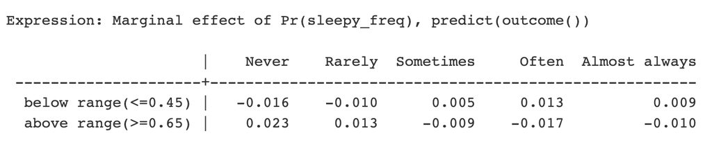

The marginal effects of **carb_level** indicates that when compared to people with carbs intake ratio in suggested range, people with lower carbs intake ratio are 1.6% less likely to never feel sleepy and 0.9% more likely to almost always feel sleepy. People with higher carbs intake ratio are 2.3% more likely to never feel sleepy and 1% less likely to almost always feel sleepy.

The output does not provide evidence that people with higher carbohydrate intake in general feel more sleepy during the day. In fact, carbohydrates can be divided into three main groups: sugar, starch and fibre. To study each of their specific effects, a more detailed analysis can be done in the future.

## References

[Ordered Logit Models – Basic & Intermediate Topics](https://www3.nd.edu/~rwilliam/stats3/Ologit01.pdf)  
[gologit2: Generalized Logistic Regression/ Partial Proportional Odds](https://www3.nd.edu/~rwilliam/gologit2/NASUG2005.pdf)  
[Ordinal regression models: Problems,solutions, and problems with the solutions](https://www.stata.com/meeting/germany08/GSUG2008.pdf)  
[HOW DO I INTERPRET THE COEFFICIENTS IN AN ORDINAL LOGISTIC REGRESSION IN R?](https://stats.idre.ucla.edu/r/faq/ologit-coefficients/)  
[Why do we need carbs?](https://www.nhs.uk/live-well/healthy-weight/why-we-need-to-eat-carbs/)  
[Does Eating Carbs Make You Sleepy?](https://www.livestrong.com/article/530662-does-eating-carbs-make-you-sleepy/)